# Datos longitudinales

Materia: Análisis de datos correlacionados

Marco Antonio Andrade Barrera

Febrero 7, 2019

## Precios y utilidades de empresas que cotizan en el mercado de valores de Estados Unidos de América

En este conjunto de datos se tienen 7 observaciones en el tiempo (aunque de ser necesario se pueden obtener más, un conjunto de datos semanalmente). Las fechas disponibles ahora son:

```r
sapply(strsplit(x = list.files("dta/"),split = " "), function(d) d[1])
```

```
## [1] "2018-09-16" "2018-09-23" "2018-09-30" "2018-10-06" "2018-11-11"
## [6] "2018-11-18" "2018-11-26"
```

```r
#cargar uno de los conjuntos
dta <- read.csv("dta/2018-11-26 dta.csv",stringsAsFactors = F)
```

En seguida se muestran algunos de los registros que componen las tablas de esta base de datos y su estructura.

```r
head(dta)
```

```
##   id       date tickers         Sector                            Industry
## 1  1 11/26/2018     AAL       Services                      Major Airlines
## 2  2 11/26/2018    AAPL Consumer Goods                Electronic Equipment
## 3  3 11/26/2018    ABMD     Healthcare      Medical Appliances & Equipment
## 4  4 11/26/2018    ACHC     Healthcare         Specialized Health Services
## 5  5 11/26/2018    ACLS     Technology Semiconductor Equipment & Materials
## 6  6 11/26/2018     ACN     Technology     Information Technology Services
##   File     P.it   P.ip        rip       rit_1      rbarip         sip
## 1    1  36.6400  37.95 0.11752305 0.127488877 0.111542284 0.014709318
## 2    2 196.8687 172.29 0.06889547 0.050573360 0.056000009 0.005436063
## 3    3 356.6300 299.41 0.01032030 0.007971864 0.007159595 0.001259298
## 4    3  38.1650  31.65 0.07519747 0.058072289 0.063299987 0.005777075
## 5    3  17.4050  17.90 0.08547486 0.097914253 0.070846333 0.017667572
## 6    1 161.0400 156.93 0.04294909 0.042761072 0.041043540 0.001514630
##          Rip        bP         cP           dP
## 1 0.06017311  34.98344   53.38037    497.05550
## 2 0.06812754 234.70855  580.99733  -1159.20151
## 3 0.04251975 387.61325 1050.89656 -28824.01996
## 4 0.04251975  40.98340   96.83097    426.02265
## 5 0.07121319  15.62592   32.72097     16.61246
## 6 0.07121319 157.61999  354.36272 -10671.36780
```

```r
str(dta)
```

```
## 'data.frame':    187 obs. of  16 variables:
##  $ id      : int  1 2 3 4 5 6 7 8 9 10 ...
##  $ date    : chr  "11/26/2018" "11/26/2018" "11/26/2018" "11/26/2018" ...
##  $ tickers : chr  "AAL" "AAPL" "ABMD" "ACHC" ...
##  $ Sector  : chr  "Services" "Consumer Goods" "Healthcare" "Healthcare" ...
##  $ Industry: chr  "Major Airlines" "Electronic Equipment" "Medical Appliances & Equipment" "Specialized Health Services" ...
##  $ File    : int  1 2 3 3 3 1 1 3 1 2 ...
##  $ P.it    : num  36.6 196.9 356.6 38.2 17.4 ...
##  $ P.ip    : num  38 172.3 299.4 31.6 17.9 ...
##  $ rip     : num  0.1175 0.0689 0.0103 0.0752 0.0855 ...
##  $ rit_1   : num  0.12749 0.05057 0.00797 0.05807 0.09791 ...
##  $ rbarip  : num  0.11154 0.056 0.00716 0.0633 0.07085 ...
##  $ sip     : num  0.01471 0.00544 0.00126 0.00578 0.01767 ...
##  $ Rip     : num  0.0602 0.0681 0.0425 0.0425 0.0712 ...
##  $ bP      : num  35 234.7 387.6 41 15.6 ...
##  $ cP      : num  53.4 581 1050.9 96.8 32.7 ...
##  $ dP      : num  497.1 -1159.2 -28824 426 16.6 ...
```

En total se se tienen 187 *tickers* o nombres con los cuales se representa una empresa en el mercado de valores. Cada *ticker* está asociado a un Sector y una industria. Los sectores se pueden considerar como grupos de empresas que a la vez contienen industrias. Los sectores no comparten industrias. En seguida se muestra un resumen del número de tickers dentro de cada grupo.

```r
table(dta$Sector)
```

```
##
##  Basic Materials   Consumer Goods        Financial       Healthcare
##                9               20               25               30
## Industrial Goods         Services       Technology        Utilities
##               20               37               44                2
```

```r
table(dta$Industry)
```

```
##
##    Aerospace/Defense - Major Diversified
##                                        1
##    Aerospace/Defense Products & Services
##                                        6
##          Air Delivery & Freight Services
##                                        3
##                           Apparel Stores
##                                        1
##                               Appliances
##                                        1
##                     Application Software
##                                        5
##                         Asset Management
##                                        4
##               Auto Manufacturers - Major
##                                        1
##                               Auto Parts
##                                        4
##                        Auto Parts Stores
##                                        1
##                     Auto Parts Wholesale
##                                        1
##                  Beverages - Soft Drinks
##                                        1
##        Beverages - Wineries & Distillers
##                                        1
##                            Biotechnology
##                                       13
##                       Business Equipment
##                                        1
##                        Business Services
##                                        5
##             Business Software & Services
##                                        3
##              Catalog & Mail Order Houses
##                                        1
##                             CATV Systems
##                                        1
##                               Cigarettes
```

[output cut: 130 more lines]

```
##                                        1
##                             Steel & Iron
##                                        2
##                 Surety & Title Insurance
##                                        1
##                       Technical Services
##                                        1
##               Textile - Apparel Clothing
##                                        2
## Textile - Apparel Footwear & Accessories
##                                        1
##                         Waste Management
##                                        1
##                  Wireless Communications
##                                        1
```

Los componentes de esta base datos son:

- id: indentificador único, consecutivo
- date: fecha en la que se capturó la información
- tickers: nombre indentificador con el cual la empresa se lista en el mercado de valores
- Sector: sector al que pertenece la empresa
- Industry: industria a la que pertenece la empresa
- File: es una clasificación sobre el rendimiento en el precio de la acción de la empresa durante el periodo 2012-2017. 1 significa Alto rendimiento, 2 rendimiento medio y 3 rendimiento bajo
- P.it: es un precio medio de la empresa durante el mes en cuestión. $P_{i,mes} = \frac{maxPrecio_{i,mes} + minPrecio_{i,mes}}{2}$
- P.ip: último precio reportado para la acción de la empresa al momento de capturar los datos
- rip: última utilidad reportada por la empresa dividida por el último precio reportado para la acción $r_{i,p} = \frac{U_{i,p}}{P_{i,p}}$
- rit_1: cociente entre la utilidad reportada al último día del mes anterior (t-1) y el último precio reportado del mes anterior (t-1) $r_{i,t-1} = \frac{U_{i,t-1}}{P_{i,t-1}}$
- rbarip: media aritmética de los últimos 12 meses $\bar{r}_{i,p} = (r_{i,t} + r_{i,t-1} + \cdots + r_{i,t-11})/12$
- sip: es la desviación estándar (muestral) de las últimas 12 $r_{i,t}$, es decir, $S_{i,p} = \sqrt{\frac{\sum_{j=0}^{11} {(r_{i,t-j} - \bar{r}_{i,p})^2}}{11}}$

-Rip: media aritmética de las relaciones U/P de todas las empresas que están en la misma sector que la empresa $i$ en el tiempo $p$, considerando en el promedio a la empresa $i$. Para un sector particular $s$, se calcula el promedio de la variablw $Rip$ de todas las empresas dentro del sector $s$.

Finalmente, las variables $bP$, $cP$ y $dP$ son funciones de las variables anteriores, de tal manera que se ajusta el modelo siguiente:

$P_{i,t} = b \cdot P_{i,p} \cdot \big( 1 + \frac{r_{i,p} - r_{i,t-1}}{r_{i,t-1}} \big) + c \cdot P_{i,p} \cdot \big( 1 + \frac{r_{i,p} - \bar{r}_{i,p} }{s_{i,p}} \big) + d \cdot P_{i,p} \cdot \big( 1 + \frac{\bar{r}_{i,p} - R_{i,p}}{s_{i,p} / \sqrt{12} } \big) + e_{i,t}$

Lo que se quiere explicar el precio medio de la empresa durante el precio en cuestión. Sencillamente, si la predicción del modelo está por arriba del último precio entonces se dice que la empresa está barata y podría ser un indcador de compra. Por el contrario, si la predicción se encuentra por abajo del último precio entonces se dice que la empresa está cara y podría ser un indicador de venta.

Sólo como referencia, se presenta el ajuste del modelo utilizando los datos del 2018-11-26. Observése los impresionantes valores de $R^2$ y $p-value$.

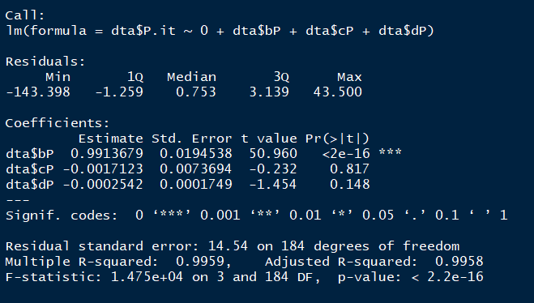

# Referencias

1. Zamudio Sánchez, F. J., 1979. Modelo estocástico para seleccionar acciones en el mercado de valores. Tesis. Colegio de Postgraduados. México.
2. Yahoo finance. Ticker Profile. Example: https://finance.yahoo.com/quote/SRE/profile?p=SRE.
3. Zacks earnings. Earnings Announcements. Example: https://www.zacks.com/stock/research/SRE/earnings-announcements.